# Reproducible Research - Course Project 1

Alexander Baker

2017-12-05

## Loading and Preprocessing the Data

The first step is to clear the data environment, download the data, load it into R and process it into a format suitable for analysis.

```r
activity <- read.csv(file="activity.csv", head=TRUE,sep=",")
summary(activity)
```

```
##      steps                date          interval
##  Min.   :  0.00   2012-10-01:  288   Min.   :   0.0
##  1st Qu.:  0.00   2012-10-02:  288   1st Qu.: 588.8
##  Median :  0.00   2012-10-03:  288   Median :1177.5
##  Mean   : 37.38   2012-10-04:  288   Mean   :1177.5
##  3rd Qu.: 12.00   2012-10-05:  288   3rd Qu.:1766.2
##  Max.   :806.00   2012-10-06:  288   Max.   :2355.0
##  NA's   :2304     (Other)   :15840
```

```r
library(ggplot2) #load ggplot2 for later plotting
library(lattice) #load lattice for later plotting
```

## What is the mean and median total number of steps taken per day?

Next we will determine (a) the total number of steps taken per day, prepare (b) a histogram of the total number of steps taken each day and calculate (c) the mean and median total number of steps taken per day.

```r
#the total number of steps taken per day
stepsperday <- aggregate(steps ~ date, activity, sum)
head(stepsperday)
```

```
##         date steps
## 1 2012-10-02   126
## 2 2012-10-03 11352
## 3 2012-10-04 12116
## 4 2012-10-05 13294
## 5 2012-10-06 15420
## 6 2012-10-07 11015
```

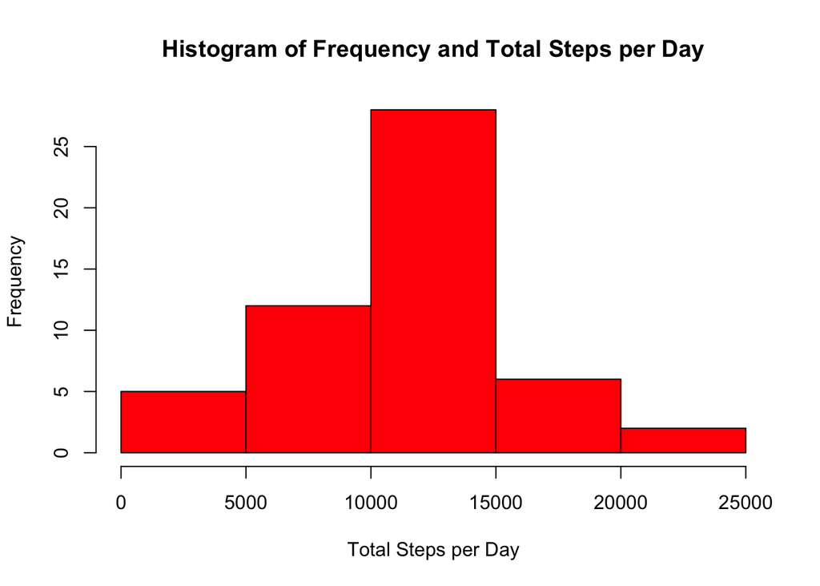

```r
# a histogram of the total number of steps taken each day
hist(stepsperday$steps, main = paste("Histogram of Frequency and Total Steps per Day"), col="red", xlab="Total Steps per Day")
```

```r
# the mean and median total number of steps taken per day
perdmean <- mean(stepsperday$steps)
perdmean
```

```
## [1] 10766.19
```

```r
perdmedian <- median(stepsperday$steps)
perdmedian
```

```
## [1] 10765
```

## What is the average daily activity pattern?

We can see from a time series plot the 5-minute interval and the average number of steps taken, averaged across all days.

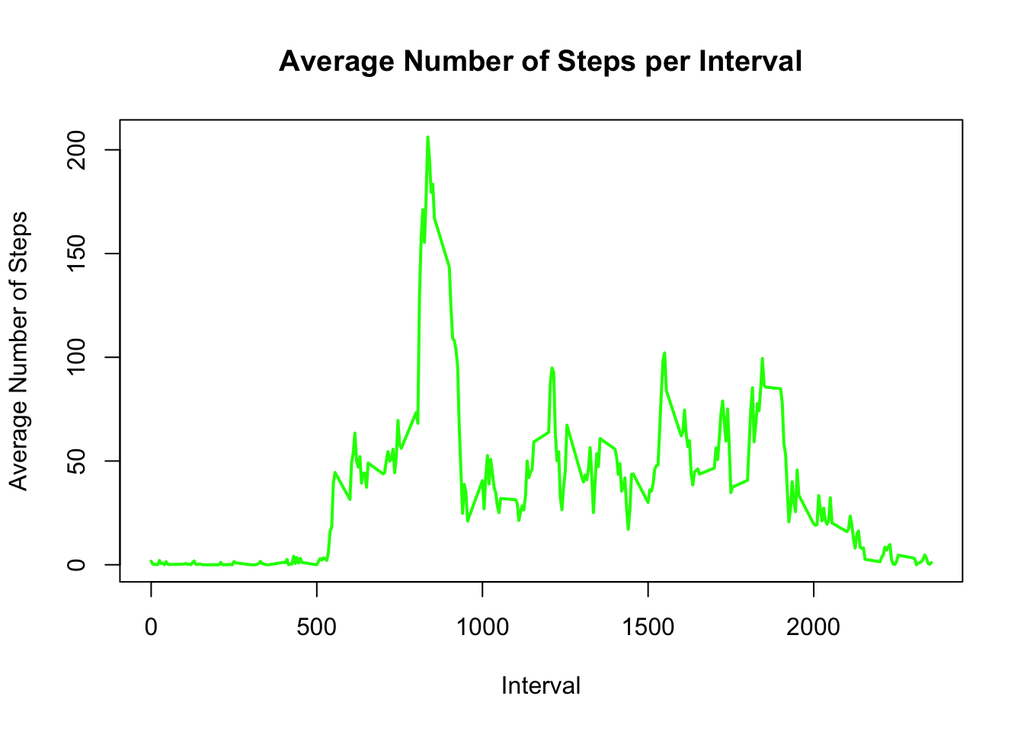

```r
avg_steps <- aggregate(activity$steps, by=list(activity$interval), mean, na.rm=TRUE)
names(avg_steps) <- c("interval", "mean")
plot(avg_steps$interval, avg_steps$mean, type = "l", col="green", lwd = 2, xlab="Interval", ylab="Average Number of Steps", main="Average Number of Steps per Interval")
```

The 5-minute interval, on average across all the days in the dataset, that contains the maximum number of steps is:

```r
avg_steps[which.max(avg_steps$mean), ]$interval
```

```
## [1] 835
```

## Imputting Missing Values

There are a number of days and intervals where there are missing values (coded as NA). The presence of missing days may introduce bias into calculations.

```r
# (a) determine the total number of missing values in the dataset
sum(is.na(activity))
```

```
## [1] 2304
```

```r
# (b) execute a strategy for filling all of the missing values in the dataset and create a new dataset equal to the original dataset with the missing data filled in.

imputed_pre <- avg_steps$mean[match(activity$interval, avg_steps$interval)]
imputed_act <- transform(activity, steps = ifelse(is.na(activity$steps), yes = imputed_pre, no = activity$steps))
imputed_total <- aggregate(steps ~ date, imputed_act, sum)
names(imputed_total) <- c("date", "steps")
```

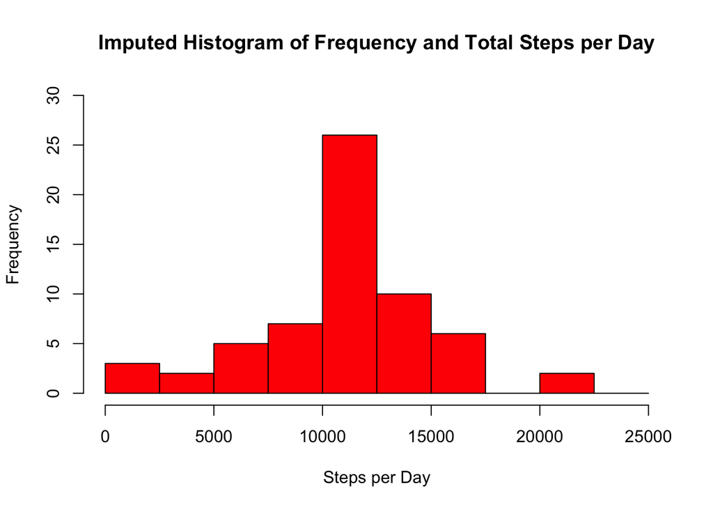

```r
hist(imputed_total$steps, col = "red", xlab = "Steps per Day", ylim = c(0,30), main = "Imputed Histogram of Frequency and Total Steps per Day", breaks = seq(0,25000,by=2500))
```

The imputed mean and median are:

```r
imputed_mean <- mean(imputed_total$steps)
imputed_mean
```

```
## [1] 10766.19
```

```r
imputed_median<- median(imputed_total$steps)
imputed_median
```

```
## [1] 10766.19
```

## Are there differences in activity patterns between weekdays and weekends?

In order to discover whether or not there are differences between weekday and weekend, we will create a new factor variable and make a panel plot of the average number of steps taken averaged across weekday and weekend days.

```r
activity$date <- as.Date(strptime(activity$date, format="%Y-%m-%d"))
activity$datetype <- sapply(activity$date, function(x) {
        if (weekdays(x) == "Saturday" | weekdays(x) =="Sunday")
                {y <- "Weekend"} else
                {y <- "Weekday"}
                y
        })
head(activity)
```

```
##   steps       date interval datetype
## 1    NA 2012-10-01        0  Weekday
## 2    NA 2012-10-01        5  Weekday
## 3    NA 2012-10-01       10  Weekday
## 4    NA 2012-10-01       15  Weekday
## 5    NA 2012-10-01       20  Weekday
## 6    NA 2012-10-01       25  Weekday
```

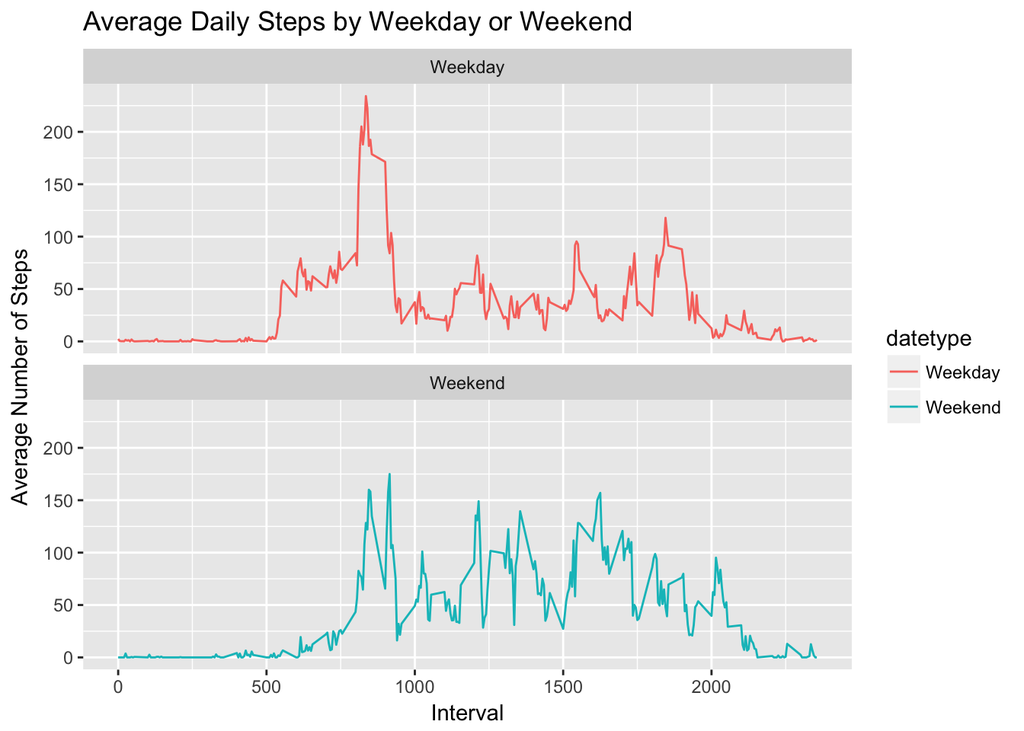

```r
activity_by_date <- aggregate(steps~interval + datetype, activity, mean, na.rm = TRUE)
plot<- ggplot(activity_by_date, aes(x = interval , y = steps, color = datetype)) +
       geom_line() +
       labs(title = "Average Daily Steps by Weekday or Weekend", x = "Interval", y = "Average Number of Steps") +
       facet_wrap(~datetype, ncol = 1, nrow=2)
print(plot)
```

We can see from this data that there is an early and higher peak during weekdays, but higher sustained activity on weekends.